# A Project on Practical Machine Learning

## Abstract

The project analysis corresponds to applying different Machine Learning algorithms to the Weight Lifting Exercises (WLE) Dataset (please see http://groupware.les.inf.puc-rio.br/har). Six persons (Carlitos, Pedro, Adelmo, Charles, Eurico and Jeremy) were asked to perform one set of ten repetitions of the Unilateral Dumbbell Biceps Curl in five different fashions, identified as classes A, B, C, D and E. All classes except A are designated as common mistakes in this weight lifting exercise. So, onley class A correspnds to the correct way of the exercise. A number of sensors were used to collect data about the execution of the exercise. The purpose of this project is to establish an effective predictive algorithm where the sensor measures serve as predictors and the outcome is the corresponding class from A to E.

The analysis uses regression tree and random forest prediction algorithm after some data cleaning. The analysis confirm that the model provided by the random forest algorithm provides almost perfect prediction accuracy.

## Data exploration and cleaning

```r
setwd("/home/mohammad/Desktop/machine learning/project1")
Trn=read.table("pml-training.csv",sep = ",", na.strings = c("NA","#DIV/0!"),header = TRUE)
b1=dim(Trn);print(b1)
```

```
## [1] 19622   160
```

```r
Tst=read.table("pml-testing.csv",sep = ",", na.strings = c("NA","#DIV/0!"),header = TRUE)
b2=dim(Tst);print(b2)
```

```
## [1]  20 160
```

#### Cleaning training dataset with sub partitions

```r
miss = is.na(Trn);c=.95*b1[1] #removing column with more than 95% missing values
remov = which(colSums(miss) > c);Trn = Trn[, -remov]
Trn=Trn[,-(1:7)]#First 7 column has nothing to do with classification
names(Trn)
```

```
##  [1] "roll_belt"            "pitch_belt"           "yaw_belt"
##  [4] "total_accel_belt"     "gyros_belt_x"         "gyros_belt_y"
##  [7] "gyros_belt_z"         "accel_belt_x"         "accel_belt_y"
## [10] "accel_belt_z"         "magnet_belt_x"        "magnet_belt_y"
## [13] "magnet_belt_z"        "roll_arm"             "pitch_arm"
## [16] "yaw_arm"              "total_accel_arm"      "gyros_arm_x"
## [19] "gyros_arm_y"          "gyros_arm_z"          "accel_arm_x"
## [22] "accel_arm_y"          "accel_arm_z"          "magnet_arm_x"
## [25] "magnet_arm_y"         "magnet_arm_z"         "roll_dumbbell"
## [28] "pitch_dumbbell"       "yaw_dumbbell"         "total_accel_dumbbell"
## [31] "gyros_dumbbell_x"     "gyros_dumbbell_y"     "gyros_dumbbell_z"
## [34] "accel_dumbbell_x"     "accel_dumbbell_y"     "accel_dumbbell_z"
## [37] "magnet_dumbbell_x"    "magnet_dumbbell_y"    "magnet_dumbbell_z"
## [40] "roll_forearm"         "pitch_forearm"        "yaw_forearm"
## [43] "total_accel_forearm"  "gyros_forearm_x"      "gyros_forearm_y"
## [46] "gyros_forearm_z"      "accel_forearm_x"      "accel_forearm_y"
## [49] "accel_forearm_z"      "magnet_forearm_x"     "magnet_forearm_y"
## [52] "magnet_forearm_z"     "classe"
```

```r
dim(Trn);set.seed(1);library(caret)
```

```
## [1] 19622    53
```

```r
inTrain <- createDataPartition(y=Trn$classe, p=0.75, list=FALSE)
training <- Trn[inTrain,];dim(training)
```

```
## [1] 14718    53
```

```r
testing <- Trn[-inTrain,];dim(testing)
```

```
## [1] 4904   53
```

#### Cleaning testing dataset

```r
miss = is.na(Tst);c=.95*b2[1] #removing column with more than 95% missing values
remov = which(colSums(miss) > c);Tst = Tst[, -remov]
Tst=Tst[,-(1:7)]#First 7 column has nothing to do with classification
dim(Tst)
```

```
## [1] 20 53
```

## Model Building

#### Regression Tree

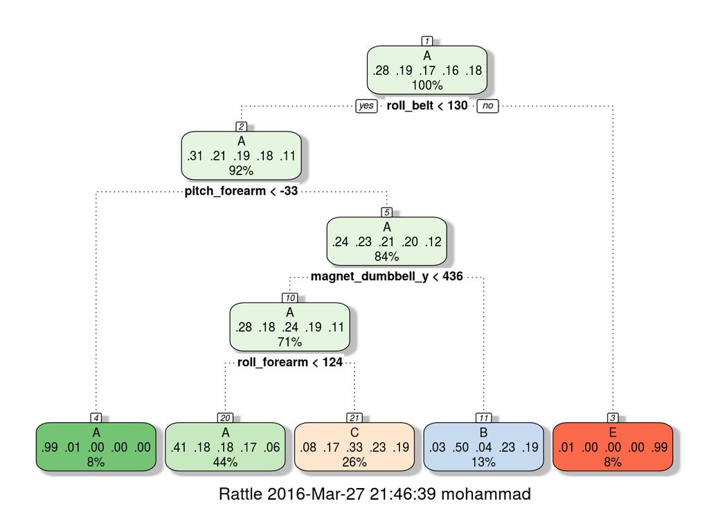

```r
library(caret);library(rattle)
mfit1<-train(classe~.,method="rpart",data=training)
fancyRpartPlot(mfit1$finalModel)
```

```r
confusionMatrix(testing$classe, predict(mfit1, newdata=testing))
```

```
## Confusion Matrix and Statistics
##
##           Reference
## Prediction    A    B    C    D    E
##          A 1260   28  102    0    5
##          B  387  326  236    0    0
##          C  402   24  429    0    0
##          D  348  140  316    0    0
##          E  114  118  225    0  444
##
## Overall Statistics
##
##                Accuracy : 0.5014
##                  95% CI : (0.4873, 0.5155)
##     No Information Rate : 0.512
##     P-Value [Acc > NIR] : 0.9332
##
##                   Kappa : 0.3491
##  Mcnemar's Test P-Value : NA
##
## Statistics by Class:
##
##                      Class: A Class: B Class: C Class: D Class: E
## Sensitivity            0.5018  0.51258  0.32798       NA  0.98886
## Specificity            0.9436  0.85403  0.88154   0.8361  0.89742
## Pos Pred Value         0.9032  0.34352  0.50175       NA  0.49279
## Neg Pred Value         0.6435  0.92162  0.78291       NA  0.99875
## Prevalence             0.5120  0.12969  0.26672   0.0000  0.09156
## Detection Rate         0.2569  0.06648  0.08748   0.0000  0.09054
## Detection Prevalence   0.2845  0.19352  0.17435   0.1639  0.18373
## Balanced Accuracy      0.7227  0.68330  0.60476       NA  0.94314
```

#### Random Forest

```r
library(caret);library(randomForest)
mfit2 = randomForest(classe~., data=training, ntree = 100)
pT = predict(mfit2, newdata = testing)
confusionMatrix(pT, testing$classe)
```

```
## Confusion Matrix and Statistics
##
##           Reference
## Prediction    A    B    C    D    E
##          A 1392    3    0    0    0
##          B    1  945    2    0    0
##          C    1    1  852    5    1
##          D    0    0    1  798    1
##          E    1    0    0    1  899
##
## Overall Statistics
##
##                Accuracy : 0.9963
##                  95% CI : (0.9942, 0.9978)
##     No Information Rate : 0.2845
##     P-Value [Acc > NIR] : < 2.2e-16
##
##                   Kappa : 0.9954
##  Mcnemar's Test P-Value : NA
##
## Statistics by Class:
##
##                      Class: A Class: B Class: C Class: D Class: E
## Sensitivity            0.9978   0.9958   0.9965   0.9925   0.9978
## Specificity            0.9991   0.9992   0.9980   0.9995   0.9995
## Pos Pred Value         0.9978   0.9968   0.9907   0.9975   0.9978
## Neg Pred Value         0.9991   0.9990   0.9993   0.9985   0.9995
## Prevalence             0.2845   0.1935   0.1743   0.1639   0.1837
## Detection Rate         0.2838   0.1927   0.1737   0.1627   0.1833
## Detection Prevalence   0.2845   0.1933   0.1754   0.1631   0.1837
## Balanced Accuracy      0.9985   0.9975   0.9973   0.9960   0.9986
```

```r
Accuracy=sum(pT==testing$classe)/dim(testing)[1];print(Accuracy)
```

```
## [1] 0.9963295
```

The model yielded a 99.6% prediction accuracy.

## Cross validation

We use cross validation method in random forest.

```r
#mfit3=train(classe~.,data=training,method="rf",trControl=trainControl(method = "cv", number = 4,allowParallel=T))
#It has been run in parallel and save to mfit3.rda
load(file = "mfit3.rda")
mfit3
```

```
## Random Forest
##
## 14718 samples
##    52 predictors
##     5 classes: 'A', 'B', 'C', 'D', 'E'
##
## No pre-processing
## Resampling: Cross-Validated (4 fold)
## Summary of sample sizes: 11038, 11037, 11039, 11040
## Resampling results across tuning parameters:
##
##   mtry  Accuracy   Kappa      Accuracy SD  Kappa SD
##    2    0.9914393  0.9891707  0.001409898  0.001782821
##   27    0.9917111  0.9895144  0.001095952  0.001385240
##   52    0.9846453  0.9805753  0.004444451  0.005622761
##
## Accuracy was used to select the optimal model using  the largest value.
## The final value used for the model was mtry = 27.
```

```r
pred1=predict(mfit3,testing);table(pred1,testing$classe)
```

```
##
## pred1    A    B    C    D    E
##     A 1391    4    0    0    0
##     B    1  944    3    0    0
##     C    2    1  850    7    1
##     D    0    0    2  796    3
##     E    1    0    0    1  897
```

```r
Accuracy=sum(pred1==testing$classe)/dim(testing)[1];print(Accuracy)
```

```
## [1] 0.9946982
```

The model yielded a 99.5% prediction accuracy.

## Prediction on testing data

```r
library(caret);library(randomForest)
predict(mfit1,Tst)#For Regression Tree
```

```
##  [1] C A C A A C C A A A C C C A C A A A A C
## Levels: A B C D E
```

```r
predict(mfit2,Tst)#For Random Forest
```

```
##  1  2  3  4  5  6  7  8  9 10 11 12 13 14 15 16 17 18 19 20
##  B  A  B  A  A  E  D  B  A  A  B  C  B  A  E  E  A  B  B  B
## Levels: A B C D E
```

```r
predict(mfit3,Tst)#For Random Forest with cross validation
```

```
##  [1] B A B A A E D B A A B C B A E E A B B B
## Levels: A B C D E
```

## References

1. Relevant information collected from http://groupware.les.inf.puc-rio.br/har.
2. G. James, D. Witten, T. Hastie, R. Tibshirani. An Introduction to Statistical Learning with Applications in R, Springer Verlag (2013). ISBN: 978-1-4614-7138-7.
3. T. Hastie, R. Tibshirani, J. Friedman. The Elements of Statistical Learning , Springer Verlag (2009). ISBN: 978-0-3878-4857-0.